# Healthcare Digest

**Week of October 26, 2026**Market data through: October 23, 2026Narrative created: October 26, 2026

Weekly review of healthcare services, technology, distribution, and diagnostic company performance, changes, earnings activity, and strategy narrative.

## In the News

### Executive Summary

- **ACA integrity policy moved from retrospective enrollment cleanup to a redesigned 2028 enrollment process.** CMS estimates mandatory annual verification would reduce Exchange enrollment by 332,500, lower advance premium-tax-credit payments by $7.6 billion annually and modestly worsen risk pools.
- **Molina put numbers behind the Medicaid margin-turn thesis.** Its early 2027 view places rates near 6% against 5.5%-6% medical-cost trend—better than the recent rate shortfall, but not yet a wide margin-recovery spread.
- **Electronic prior authorization gained a commercial-market demand signal.** Five major employers want the capabilities being built for regulated plans made available to their self-funded plans, increasing pressure on TPAs to deploy common FHIR workflows across lines of business.
- **Two transactions advanced distinct provider-integration models.** Horizon plans to own a major New Jersey ambulatory network, while Kaiser-backed Risant is adding a third health system to its reusable value-based-care platform.
- **DOJ created an explicit resolution path for legacy healthcare False Claims Act exposure.** The six-month pilot may accelerate internal audits, repayment decisions and transaction diligence.
- **Overall environment:** improved for Medicaid margin visibility and administrative-technology demand; deteriorated for ACA enrollment continuity; broadly unchanged in aggregate.

### 1. CMS makes active verification a condition of subsidized Exchange enrollment

**What happened**

On October 23, CMS proposed requiring Exchanges to verify household income and size, citizenship or eligible noncitizen status, other qualifying coverage and residency before providing advance premium-tax-credit payments or cost-sharing reductions. Starting with 2028 coverage, existing members would have to return annually and confirm their information to retain financial assistance; otherwise, they could be automatically re-enrolled only without subsidies. The first proposed pre-open-enrollment verification period would begin August 1, 2027. ([CMS, *Exchange Pre-Eligibility Verification Proposed Rule*, October 23, 2026](https://www.cms.gov/newsroom/fact-sheets/exchange-pre-eligibility-verification-proposed-rule-cms-9873-p)) ([cms.gov](https://www.cms.gov/newsroom/fact-sheets/exchange-pre-eligibility-verification-proposed-rule-cms-9873-p))

CMS estimates that the proposal would reduce annual Exchange enrollment by approximately 332,500, decrease APTC spending by $7.6 billion beginning in 2028 and increase average premiums by 0.4%, or $2.89 per member per month, because administrative barriers would disproportionately deter younger and healthier consumers. ([Federal Register public-inspection document, *CMS-9873-P*, October 23, 2026](https://public-inspection.federalregister.gov/2026-21891.pdf)) ([public-inspection.federalregister.gov](https://public-inspection.federalregister.gov/2026-21891.pdf))

**Implication**

This extends the September membership-removal thesis into a permanent annual operating model. Marketplace carriers now face more churn, delayed subsidy activation, retroactive enrollment transactions and less predictable risk pools—not merely tighter broker controls. Premium revenue should decline with enrollment, although CMS acknowledges that claims may also fall and does not quantify the net margin effect.

The near-term technology demand is for eligibility orchestration, document collection, identity and residency verification, broker outreach and enrollment reconciliation. Providers face a smaller but meaningful 2028 increase in coverage gaps, bad debt and delayed care if eligible consumers fail to complete verification.

**Watch next**

Whether CMS reduces friction for passive renewals and how Exchanges operationalize retroactive subsidies and pended plan selections without generating avoidable claims and premium-reconciliation errors.

### 2. Molina quantifies a narrow Medicaid rate-trend crossover

**What happened**

Molina reported a 93% third-quarter Medicaid medical-cost ratio and said elevated medical trend appears to be plateauing as recent state rate actions begin to close the funding gap. Management’s preliminary 2027 assumptions place Medicaid rates at approximately 6% and medical-cost trend at 5.5%-6%; it also expects enrollment pressure from work requirements and more frequent eligibility reverifications. ([Molina Healthcare, *Third Quarter 2026 Financial Results*, October 21, 2026](https://molinahealthcare.gcs-web.com/news-releases/news-release-details/molina-healthcare-reports-third-quarter-2026-financial-results); [earnings-call transcript, October 22, 2026](https://www.fool.com/earnings/call-transcripts/2026/10/22/molina-healthcare-moh-q3-2026-earnings-call-transcript/)) ([molinahealthcare.gcs-web.com](https://molinahealthcare.gcs-web.com/news-releases/news-release-details/molina-healthcare-reports-third-quarter-2026-financial-results?utm_source=openai))

Elevance provided corroborating, though less specific, evidence: premium increases offset membership attrition, while Medicaid enrollment fell 4.9% year over year. Elevance’s consolidated benefit ratio improved primarily because of Medicare Advantage and individual ACA performance, so its release does not establish a fully recovered Medicaid margin. ([Elevance Health, *Third Quarter 2026 Results*, October 21, 2026](https://www.sec.gov/Archives/edgar/data/1156039/000115603926000068/a3q2026elvearningsrelease.htm)) ([sec.gov](https://www.sec.gov/Archives/edgar/data/1156039/000115603926000068/a3q2026elvearningsrelease.htm))

**Implication**

The new evidence changes the Medicaid thesis from “rates should eventually catch up” to “rates may approximately match trend in 2027.” That is an inflection, not normalization: a zero-to-50-basis-point spread leaves little protection against pharmacy, outpatient or acuity surprises.

Plans should continue prioritizing acuity detection, eligibility forecasting, payment integrity and high-cost case management rather than assuming broad margin expansion. Providers should expect continued contracting discipline even where state rates improve, because membership attrition and mix changes can offset nominal rate gains.

**Watch next**

Whether fourth-quarter utilization remains within Molina’s 5.5%-6% trend assumption and whether state rate updates include retrospective relief or only prospective increases.

### 3. Self-funded employers push prior-authorization infrastructure beyond CMS-0057

**What happened**

CMS and the Department of Labor announced on October 21 that Amazon, Axon, Google, Meta and Oracle support making the capabilities developed under the 2025 Prior Authorization Pledge available to self-funded employer plans. Those capabilities include FHIR-based electronic prior authorization, fewer services requiring authorization, greater transparency and more real-time decisions. The employer statement is voluntary and does not itself impose deadlines or performance standards. ([CMS, *Leading Employers Back Expansion of Electronic Prior Authorization to Self-Funded Health Plans*, October 21, 2026](https://www.cms.gov/newsroom/press-releases/leading-employers-back-expansion-electronic-prior-authorization-self-funded-health-plans)) ([cms.gov](https://www.cms.gov/newsroom/press-releases/leading-employers-back-expansion-electronic-prior-authorization-self-funded-health-plans?utm_source=openai))

**Implication**

The regulated-plan API build is becoming a commercial platform expectation. Large employers do not want providers switching between electronic workflows for Medicare Advantage or Medicaid patients and manual workflows for employees administered by the same carrier or TPA.

This strengthens demand for reusable payer APIs, authorization-rule engines, clinical-document exchange and workflow integration. However, the immediate revenue opportunity remains dependent on TPA contract amendments and employer purchasing decisions; a pledge without adoption metrics should not be treated as equivalent to CMS-0057 compliance.

**Watch next**

Whether national TPAs commit to common deployment dates and disclose self-funded authorization volumes, decision times and real-time approval rates.

### 4. Regional integration advances through both ownership and shared platforms

**What happened**

Horizon Mutual Holdings confirmed an agreement to acquire Summit Health New Jersey, including New Jersey CityMD sites, subject to regulatory review. The transaction would place a major multispecialty and urgent-care network under the state’s dominant Blue plan. ([BINJE, *Horizon BCBS to Purchase Summit Health in Billion-Dollar Deal*, October 21, 2026](https://binje.com/sectors/health-care/horizon-bcbs-to-purchase-summit-health-in-billion-dollar-deal/)) ([binje.com](https://binje.com/sectors/health-care/horizon-bcbs-to-purchase-summit-health-in-billion-dollar-deal/?utm_source=openai))

Separately, Kaiser Permanente-backed Risant Health signed a definitive agreement to add INTEGRIS Health as its third member system after Geisinger and Cone Health. INTEGRIS operates 10 acute and 10 specialty hospitals and will retain its brand and leadership while adopting Risant’s value-based-care and technology capabilities. ([INTEGRIS Health, *INTEGRIS Health to Become Part of Risant Health*, October 21, 2026](https://integrishealth.org/resources/news/2026/october/integris-health-to-become-part-of-risant-health)) ([integrishealth.org](https://integrishealth.org/resources/news/2026/october/integris-health-to-become-part-of-risant-health?utm_source=openai))

**Implication**

Horizon is pursuing direct capture of referral, ambulatory and site-of-care economics; Risant is scaling a common operating platform across locally branded systems. Both models increase enterprise standardization and favor vendors capable of systemwide deployment, but they also concentrate purchasing authority and raise displacement risk for point solutions.

**Watch next**

Regulatory conditions on Horizon’s acquisition and evidence that Risant can reproduce its claimed operating improvements outside Geisinger and Cone’s markets.

### 5. DOJ puts a defined price range on voluntary FCA resolution

**What happened**

DOJ and HHS launched a six-month healthcare False Claims Act self-disclosure pilot on October 22. Companies must provide relevant facts and documents, describe remediation and repay the government using a 1.25-to-1.6 multiplier. In exchange, participants may receive a coordinated release under the federal FCA and specified HHS administrative authorities. Submissions are accepted through April 22, 2027; potential criminal conduct follows separate disclosure procedures. ([Department of Justice, *Healthcare False Claims Act Self-Disclosure Pilot Program*, October 22, 2026](https://www.justice.gov/opa/pr/justice-departments-civil-division-and-department-health-human-services-announce-anti-fraud)) ([justice.gov](https://www.justice.gov/opa/pr/justice-departments-civil-division-and-department-health-human-services-announce-anti-fraud?utm_source=openai))

**Implication**

The program gives plans, providers and acquirers a more calculable alternative to waiting for whistleblower litigation or enforcement. It is particularly relevant to unsupported coding, risk-adjustment deletions, billing errors and successor liabilities discovered during integration.

Expect stronger demand for retrospective claims analytics, coding validation, defensible sampling and transaction diligence. The pathway reduces uncertainty—not liability—and rewards rapid remediation before an issue expands in duration, value or senior-management involvement.

**Watch next**

Whether DOJ accepts disclosures involving conduct already subject to payer audits or government data analysis, and how coordinated releases address successor liability.

### What I'm Watching Next

- **October 27, 2026:** CMS-9873-P is scheduled for publication in the *Federal Register*. ([federalregister.gov](https://www.federalregister.gov/public-inspection/2026-21891/patient-protection-and-affordable-care-act-exchange-pre-eligibility-verification))
- **April 22, 2027:** DOJ’s healthcare FCA self-disclosure pilot closes to submissions. ([justice.gov](https://www.justice.gov/opa/pr/justice-departments-civil-division-and-department-health-human-services-announce-anti-fraud?utm_source=openai))
- **August 1, 2027:** Proposed first pre-open-enrollment verification period begins for 2028 Exchange coverage, if finalized. ([cms.gov](https://www.cms.gov/newsroom/fact-sheets/exchange-pre-eligibility-verification-proposed-rule-cms-9873-p))

### Bottom Line

The most important weekly change is CMS’s proposed conversion of subsidized Exchange enrollment into an annual active-verification process with quantified enrollment and risk-pool consequences. ACA enrollment continuity requires the closest attention. The October 27 publication of CMS-9873-P begins the formal process most likely to determine whether the 2028 integrity regime becomes a manageable verification workflow or a material new source of coverage churn.

## Notable Changes

Comparison with the final report dated October 19, 2026 (market data through October 16, 2026).

### Sectors

#### Top-three comparison

| Entity | Previous | Current | Change | Current return |
| --- | --- | --- | --- | --- |
| Precision Diagnostics | #1 | #1 | — 0 | +99.1% |
| Inpatient Non-Acute Providers | #2 | #2 | — 0 | +64.6% |
| Value-Based Care | #3 | #3 | — 0 | +53.6% |

### Stocks

#### Top-three comparison

| Entity | Previous | Current | Change | Current return |
| --- | --- | --- | --- | --- |
| 10x Genomics (TXG) | #1 | #1 | — 0 | +419.6% |
| PACS Group (PACS) | #2 | #2 | — 0 | +276.3% |
| Agilon Health (AGL) | #3 | #3 | — 0 | +270.0% |

#### Largest rank changes

| Entity | Previous | Current | Change | Current return |
| --- | --- | --- | --- | --- |
| Molina Healthcare (MOH) | #42 | #26 | ↑ 16 | +28.1% |
| Clover Health (CLOV) | #14 | #32 | ↓ 18 | +20.4% |
| Community Health Systems (CYH) | #54 | #64 | ↓ 10 | -28.8% |

### Subcategory movement since the previous report

| Subcategory | Move | Last Report, 12m Ret | Current Report, 12m Ret |
| --- | --- | --- | --- |
| Digital Health, Specialty, Benefits | +6.4% | +4.5% | +7.5% |
| Precision Diagnostics | +3.8% | +103.2% | +99.1% |
| Payers | +2.9% | +18.7% | +21.3% |
| Health System Providers | +1.8% | +10.3% | +7.0% |
| Value-Based Care | +1.7% | +51.9% | +53.6% |
| Outpatient and Home Providers | +1.2% | +39.8% | +35.0% |
| Health Care Real Estate | +0.9% | +26.5% | +26.5% |
| Inpatient Non-Acute Providers | -0.4% | +67.5% | +64.6% |
| Health IT and Data | -0.5% | -41.3% | -41.1% |
| Pharma Distribution | -1.5% | +30.4% | +25.4% |

### Largest company moves

| Direction | Company | Ticker | Move |
| --- | --- | --- | --- |
| Gain | PacBio | PACB | +22.0% |
| Gain | Amwell | AMWL | +16.2% |
| Gain | Phreesia | PHR | +16.1% |
| Decline | Medical Properties Trust | MPT | -10.3% |
| Decline | LifeMD | LFMD | -9.0% |
| Decline | Encompass Health | EHC | -3.0% |

## Subcategory Performance

| Subcategory | Companies | Market cap | 3m Return | 12m Return | 24m Return |
| --- | --- | --- | --- | --- | --- |
| Payers | 10 | $733.0B | +0.9% | +21.3% | +2.6% |
| Health System Providers | 5 | $119.8B | +21.0% | +7.0% | +35.7% |
| Inpatient Non-Acute Providers | 4 | $31.4B | +3.6% | +64.6% | +16.1% |
| Health Care Real Estate | 8 | $266.4B | -9.0% | +26.5% | +58.7% |
| Value-Based Care | 5 | $6.6B | -8.8% | +53.6% | +7.3% |
| Outpatient and Home Providers | 11 | $64.8B | -4.8% | +35.0% | +69.5% |
| Digital Health, Specialty, Benefits | 9 | $25.4B | +5.2% | +7.5% | +33.9% |
| Health IT and Data | 11 | $471.6B | +16.7% | -41.1% | -15.1% |
| Pharma Distribution | 5 | $222.6B | +12.2% | +25.4% | +85.0% |
| Precision Diagnostics | 12 | $168.6B | +29.1% | +99.1% | +204.2% |

Subcategory returns use the most recently saved market capitalizations as weights.

## Stock Performance vs. SPY

The same selected stocks appear in every chart. Each line is labeled at the right with its ticker and return for the displayed window.

### Last 6 months

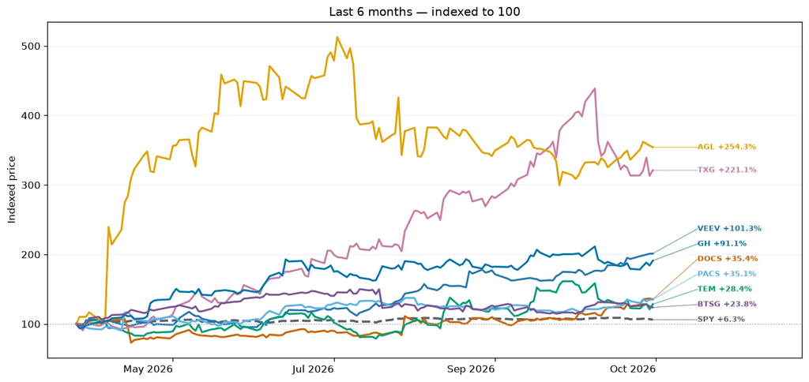

### Last 12 months

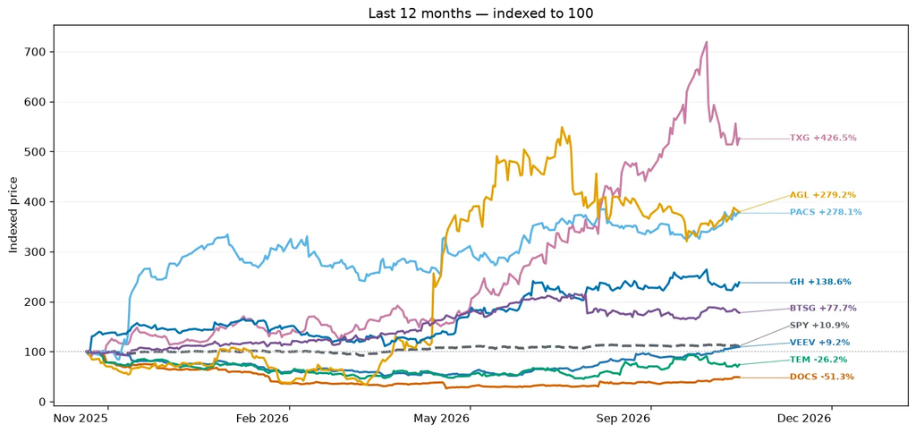

### Last 24 months

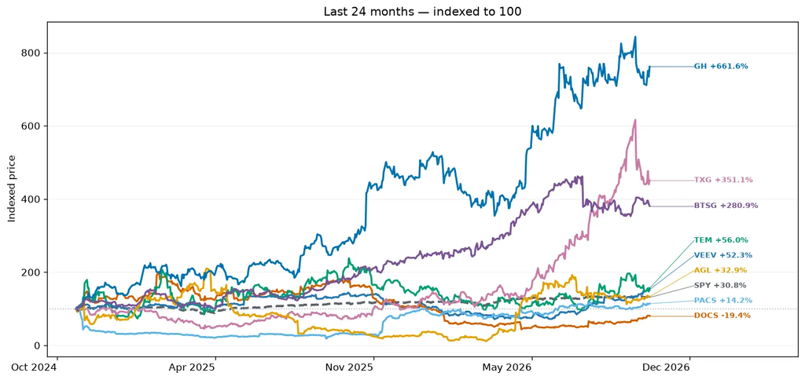

## Current Top Stocks

### Last 3 months

| Rank | Company | Ticker | Market cap | Return |
| --- | --- | --- | --- | --- |
| 1 | Veeva Systems | VEEV | $33.1B | +73.5% |
| 2 | Doximity | DOCS | $3.8B | +63.5% |
| 3 | Tempus AI | TEM | $8.5B | +58.4% |
| 4 | Definitive Healthcare | DH | $106.7M | +58.1% |
| 5 | PacBio | PACB | $447.3M | +55.1% |

### Last 12 months

| Rank | Company | Ticker | Market cap | Return |
| --- | --- | --- | --- | --- |
| 1 | 10x Genomics | TXG | $6.1B | +419.6% |
| 2 | PACS Group | PACS | $7.3B | +276.3% |
| 3 | Agilon Health | AGL | $1.4B | +270.0% |
| 4 | Illumina | ILMN | $30.7B | +169.1% |
| 5 | Lifestance Health | LFST | $4.0B | +148.7% |

### Last 24 months

| Rank | Company | Ticker | Market cap | Return |
| --- | --- | --- | --- | --- |
| 1 | Guardant Health | GH | $21.4B | +724.4% |
| 2 | 10x Genomics | TXG | $6.1B | +361.9% |
| 3 | BrightSpring Health Services | BTSG | $12.4B | +287.8% |
| 4 | Natera | NTRA | $39.4B | +243.3% |
| 5 | Aveanna Healthcare | AVAH | $2.0B | +167.1% |

## Companies by Subcategory

### PayersLast 3m: +0.9%

| Company | Ticker | Market cap | 3m Return | 12m Return | 24m Return |
| --- | --- | --- | --- | --- | --- |
| UnitedHealth | UNH | $360.3B | -0.6% | +15.3% | -25.9% |
| CVS Health | CVS | $118.1B | -13.2% | +14.1% | +65.5% |
| Humana | HUM | $43.7B | +8.4% | +45.2% | +61.9% |
| Oscar Health | OSCR | $9.4B | +9.9% | +60.7% | +91.4% |
| Molina Healthcare | MOH | $10.2B | +5.9% | +28.1% | -35.8% |
| Cigna | CI | $73.7B | +6.0% | +1.7% | -3.1% |
| Elevance | ELV | $81.5B | +16.5% | +28.5% | +3.5% |
| Clover Health | CLOV | $2.2B | +6.5% | +20.4% | +17.3% |
| Centene | CNC | $30.7B | +10.7% | +106.0% | +9.3% |
| Alignment Health | ALHC | $3.1B | -58.5% | -54.0% | -27.0% |

### Health System ProvidersLast 3m: +21.0%

| Company | Ticker | Market cap | 3m Return | 12m Return | 24m Return |
| --- | --- | --- | --- | --- | --- |
| HCA Healthcare | HCA | $87.2B | +22.7% | +4.9% | +29.0% |
| Tenet Health | THC | $20.5B | +15.1% | +27.6% | +92.1% |
| Universal Health Services | UHS | $10.2B | +20.0% | -11.3% | -7.8% |
| Community Health Systems | CYH | $417.4M | +7.0% | -28.8% | -26.8% |
| Ardent Health Partners | ARDT | $1.5B | +15.3% | -19.3% | -30.8% |

### Inpatient Non-Acute ProvidersLast 3m: +3.6%

| Company | Ticker | Market cap | 3m Return | 12m Return | 24m Return |
| --- | --- | --- | --- | --- | --- |
| The Ensign Group | ENSG | $10.4B | +1.5% | -5.6% | +14.9% |
| Acadia Healthcare | ACHC | $2.8B | -8.7% | +34.7% | -38.1% |
| Encompass Health | EHC | $11.0B | +9.9% | -1.6% | +32.8% |
| PACS Group | PACS | $7.3B | +1.7% | +276.3% | +13.2% |

### Health Care Real EstateLast 3m: -9.0%

| Company | Ticker | Market cap | 3m Return | 12m Return | 24m Return |
| --- | --- | --- | --- | --- | --- |
| Healthpeak properties | DOC | $15.1B | -13.6% | +2.6% | -13.6% |
| Ventas, Inc | VTR | $48.0B | -13.7% | +23.3% | +33.6% |
| Medical Properties Trust | MPT | $2.8B | -44.2% | — | — |
| National Health Investors | NHI | $3.7B | -16.7% | -10.8% | -10.8% |
| Omega Healthcare Investors | OHI | $15.1B | -10.6% | +14.2% | +11.3% |
| Welltower | WELL | $166.9B | -5.9% | +33.4% | +82.3% |
| CareTrust REIT | CTRE | $9.6B | -15.3% | +4.1% | +18.4% |
| Sabra Health Care REIT | SBRA | $5.3B | -12.5% | +8.2% | +4.0% |

### Value-Based CareLast 3m: -8.8%

| Company | Ticker | Market cap | 3m Return | 12m Return | 24m Return |
| --- | --- | --- | --- | --- | --- |
| Privia Health Group | PRVA | $3.0B | -12.1% | -13.8% | +27.0% |
| Astrana Health | ASTH | $1.8B | -7.1% | +12.5% | -32.7% |
| Agilon Health | AGL | $1.4B | -8.5% | +270.0% | +39.1% |
| Evolent Health | EVH | $347.6M | +13.7% | -38.5% | -80.0% |
| P3 Health | PIII | $32.7M | -57.0% | -53.2% | -79.6% |

### Outpatient and Home ProvidersLast 3m: -4.8%

| Company | Ticker | Market cap | 3m Return | 12m Return | 24m Return |
| --- | --- | --- | --- | --- | --- |
| Davita | DVA | $15.4B | -22.0% | +42.1% | +17.0% |
| Fresenius | FMS | $13.8B | -7.8% | -16.7% | +8.4% |
| Surgery Partners | SGRY | $2.0B | +0.1% | -30.9% | -46.6% |
| Option Care Health | OPCH | $3.4B | +44.1% | +11.9% | +6.0% |
| Lifestance Health | LFST | $4.0B | +18.6% | +148.7% | +88.8% |
| Chemed (Vitas) | CHE | $7.1B | +0.4% | +17.5% | -14.9% |
| Addus HomeCare | ADUS | $2.1B | +6.3% | +0.1% | -4.8% |
| Pennant Group | PNTG | $1.3B | +1.7% | +65.9% | +24.9% |
| US Physical Therapy | USPH | $1.2B | +18.7% | -5.0% | +9.6% |
| BrightSpring Health Services | BTSG | $12.4B | -17.6% | +79.3% | +287.8% |
| Aveanna Healthcare | AVAH | $2.0B | +41.6% | +41.9% | +167.1% |

### Digital Health, Specialty, BenefitsLast 3m: +5.2%

| Company | Ticker | Market cap | 3m Return | 12m Return | 24m Return |
| --- | --- | --- | --- | --- | --- |
| Teladoc | TDOC | $1.2B | -27.7% | -33.0% | -26.0% |
| Amwell | AMWL | $179.6M | +25.5% | +143.6% | +44.2% |
| Hims & Hers | HIMS | $6.4B | -1.4% | -43.2% | +27.5% |
| LifeMD | LFMD | $169.3M | -42.6% | -66.2% | -50.3% |
| Omada Health | OMDA | $1.2B | -7.7% | -26.7% | — |
| GoodRx | GDRX | $1.0B | +19.6% | -10.4% | -43.0% |
| Progyny | PGNY | $2.5B | -7.1% | +48.6% | +87.5% |
| Concentra Group | CON | $4.0B | +24.2% | +87.7% | +87.7% |
| HealthEquity | HQY | $8.8B | +9.9% | +7.7% | +18.1% |

### Health IT and DataLast 3m: +16.7%

| Company | Ticker | Market cap | 3m Return | 12m Return | 24m Return |
| --- | --- | --- | --- | --- | --- |
| Oracle-Cerner | ORCL | $374.1B | +9.7% | -55.5% | -27.3% |
| Waystar | WAY | $4.0B | +28.2% | -26.0% | +4.5% |
| Solventum | SOLV | $14.6B | +9.5% | +19.6% | +16.7% |
| Phreesia | PHR | $663.2M | +24.3% | -45.9% | -30.4% |
| Consensus Cloud Solutions | CCSI | $669.7M | +3.0% | +35.3% | +85.3% |
| Definitive Healthcare | DH | $106.7M | +58.1% | -63.6% | -74.0% |
| Iqvia | IQV | $38.7B | +34.3% | +26.7% | +30.2% |
| Health Catalyst | HCAT | $154.4M | -18.8% | -47.8% | -77.9% |
| Doximity | DOCS | $3.8B | +63.5% | -50.0% | -19.1% |
| Veeva Systems | VEEV | $33.1B | +73.5% | +10.2% | +52.2% |
| Omnicell | OMCL | $1.7B | -7.9% | +21.4% | -4.4% |

### Pharma DistributionLast 3m: +12.2%

| Company | Ticker | Market cap | 3m Return | 12m Return | 24m Return |
| --- | --- | --- | --- | --- | --- |
| McKesson | MCK | $97.2B | +19.0% | +24.8% | +97.2% |
| Cardinal Health | CAH | $54.7B | +9.4% | +54.2% | +125.1% |
| Cencora | COR | $59.6B | +6.8% | -0.5% | +41.2% |
| Accendra Health | AHCO | $912.9M | -44.1% | -35.8% | -43.5% |
| Henry Schein | HSIC | $10.2B | -0.6% | +33.1% | +21.4% |

### Precision DiagnosticsLast 3m: +29.1%

| Company | Ticker | Market cap | 3m Return | 12m Return | 24m Return |
| --- | --- | --- | --- | --- | --- |
| Natera | NTRA | $39.4B | +54.2% | +109.8% | +243.3% |
| NeoGenomics | NEO | $2.1B | +19.4% | +55.5% | +26.9% |
| BillionToOne | BLLN | $6.5B | -14.5% | — | — |
| Guardant Health | GH | $21.4B | +14.8% | +134.3% | +724.4% |
| Tempus AI | TEM | $8.5B | +58.4% | -24.2% | +55.4% |
| Illumina | ILMN | $30.7B | +38.8% | +169.1% | +89.8% |
| 10x Genomics | TXG | $6.1B | +54.6% | +419.6% | +361.9% |
| PacBio | PACB | $447.3M | +55.1% | +4.5% | +19.2% |
| QuidelOrtho | QDEL | $1.2B | -14.5% | -55.0% | -64.5% |
| Quest Diagnostics | DGX | $25.8B | +6.2% | +32.8% | +56.0% |
| Labcorp Holdings | LH | $25.3B | +10.8% | +17.7% | +43.9% |
| Certara | CERT | $1.2B | +37.5% | -18.4% | +1.3% |

## Upcoming Earnings

### Payers

| Company | Ticker | Date | Market cap | 3m Return | 12m Return |
| --- | --- | --- | --- | --- | --- |
| Centene | CNC | October 27, 2026 | $30.7B | +10.7% | +106.0% |
| Alignment Health | ALHC | October 29, 2026 | $3.1B | -58.5% | -54.0% |

### Health System Providers

| Company | Ticker | Date | Market cap | 3m Return | 12m Return |
| --- | --- | --- | --- | --- | --- |
| HCA Healthcare | HCA | October 27, 2026 | $87.2B | +22.7% | +4.9% |
| Tenet Health | THC | October 29, 2026 | $20.5B | +15.1% | +27.6% |
| Universal Health Services | UHS | October 28, 2026 | $10.2B | +20.0% | -11.3% |
| Community Health Systems | CYH | October 29, 2026 | $417.4M | +7.0% | -28.8% |

### Inpatient Non-Acute Providers

| Company | Ticker | Date | Market cap | 3m Return | 12m Return |
| --- | --- | --- | --- | --- | --- |
| Encompass Health | EHC | October 29, 2026 | $11.0B | +9.9% | -1.6% |
| The Ensign Group | ENSG | October 28, 2026 | $10.4B | +1.5% | -5.6% |

### Health Care Real Estate

| Company | Ticker | Date | Market cap | 3m Return | 12m Return |
| --- | --- | --- | --- | --- | --- |
| Welltower | WELL | October 26, 2026 | $166.9B | -5.9% | +33.4% |
| Ventas, Inc | VTR | October 27, 2026 | $48.0B | -13.7% | +23.3% |
| Medical Properties Trust | MPT | October 29, 2026 | $2.8B | -44.2% | — |

### Outpatient and Home Providers

| Company | Ticker | Date | Market cap | 3m Return | 12m Return |
| --- | --- | --- | --- | --- | --- |
| Davita | DVA | October 29, 2026 | $15.4B | -22.0% | +42.1% |
| BrightSpring Health Services | BTSG | October 30, 2026 | $12.4B | -17.6% | +79.3% |
| Chemed (Vitas) | CHE | October 28, 2026 | $7.1B | +0.4% | +17.5% |

### Digital Health, Specialty, Benefits

| Company | Ticker | Date | Market cap | 3m Return | 12m Return |
| --- | --- | --- | --- | --- | --- |
| Teladoc | TDOC | October 28, 2026 | $1.2B | -27.7% | -33.0% |

### Health IT and Data

| Company | Ticker | Date | Market cap | 3m Return | 12m Return |
| --- | --- | --- | --- | --- | --- |
| Iqvia | IQV | October 27, 2026 | $38.7B | +34.3% | +26.7% |
| Waystar | WAY | November 2, 2026 | $4.0B | +28.2% | -26.0% |
| Omnicell | OMCL | October 29, 2026 | $1.7B | -7.9% | +21.4% |

### Precision Diagnostics

| Company | Ticker | Date | Market cap | 3m Return | 12m Return |
| --- | --- | --- | --- | --- | --- |
| Illumina | ILMN | October 29, 2026 | $30.7B | +38.8% | +169.1% |
| Labcorp Holdings | LH | October 28, 2026 | $25.3B | +10.8% | +17.7% |
| Tempus AI | TEM | November 2, 2026 | $8.5B | +58.4% | -24.2% |
| NeoGenomics | NEO | October 28, 2026 | $2.1B | +19.4% | +55.5% |

## Recent Earnings Highlights — 3m Ret

Companies covered in this section:

- Elevance (ELV)
- Quest Diagnostics (DGX)
- Molina Healthcare (MOH)

### Elevance (ELV) +16.5%

**Reported:** October 21, 2026 · [Google Finance earnings page](https://www.google.com/finance/quote/ELV:NYSE?tab=earnings&hl=en)

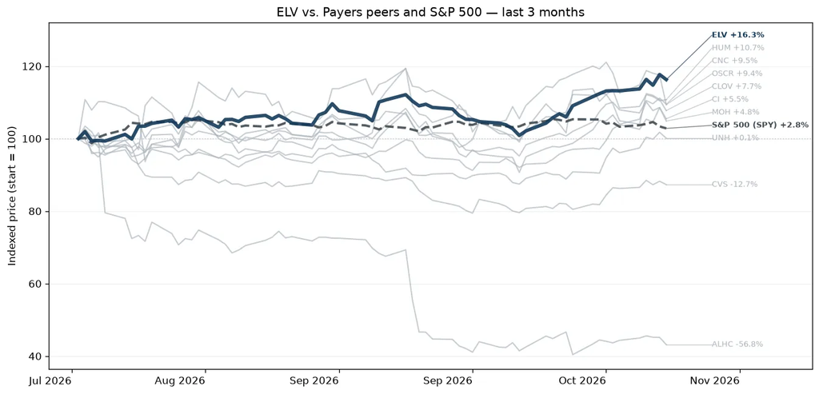

#### Earnings Call Summary

Elevance Health reported strong Q3 2026 results with adjusted EPS of $6.99, beating expectations. Operating revenue rose nearly 1% to $50.4B, driven by premium yields and CarelonRx revenue. The company raised its full-year 2026 adjusted EPS guidance to at least $29.00 and increased its earnings baseline to at least $26.75.

#### At a Glance

- **Elevance Health Beats Q3 Expectations:** Elevance Health reported a Q3 2026 adjusted EPS of $6.99, significantly beating the estimated $4.695, and posted an operating revenue of $50.44 billion, which surpassed the expected $49.16 billion.
- **Strong Operating Performance Across Portfolios:** The company's benefit expense ratio improved 70 basis points to 90.6%, driven by operating outperformance in Medicaid, Medicare Advantage, and Individual ACA lines.
- **Management Lifts Full-Year Guidance Outlook:** Elevance Health raised its full-year 2026 adjusted EPS guidance to at least $29.00 and increased its baseline to at least $26.75, reaffirming a target of 12% adjusted EPS growth for 2027.
- **Carelon Segment Boosts Top-Line Gains:** The Carelon services segment reported a 5% increase in operating revenue to $19.3 billion, with operating gains rising 17% to $900 million.
- **Non-Operating Items Overstate Core Beat:** Analysts noted a quality caveat in the performance, as roughly $1.85 per share of the earnings beat stemmed from non-operating benefits like investment valuation adjustments.

#### Key Moments from the Call

- **2m 0s — Full-Year Guidance and Baseline Increase:** Elevance Health raised its 2026 adjusted EPS guidance to at least $29.00 and lifted its baseline to at least $26.75, giving investors enhanced visibility and reinforcing confidence in delivering at least 12% adjusted EPS growth in 2027.
- **11m 50s — Medicaid Margin Trough Confirmed:** Management confirmed that 2026 represents the trough for Medicaid margins. Favorable July 1st rate actions helped stabilize performance, paving a clear path for margin expansion in 2027 as states adjust rates to match cost trends.
- **32m 50s — Commercial Pricing and IDR Management:** Commercial Group trends remain stable within pricing assumptions, which anticipate low double-digit cost trends for 2026 and 2027. Management proactively priced for industry-wide Independent Dispute Resolution pressures, particularly within its ASO block.
- **42m 52s — Individual ACA Outperformance:** The Individual ACA business outperformed due to stronger-than-expected membership retention and slower emerging costs from bronze plans, prompting an increased year-end target of at least 1.2 million members and higher full-year margin expectations.

### Quest Diagnostics (DGX) +6.2%

**Reported:** October 22, 2026 · [Google Finance earnings page](https://www.google.com/finance/quote/DGX:NYSE?tab=earnings&hl=en)

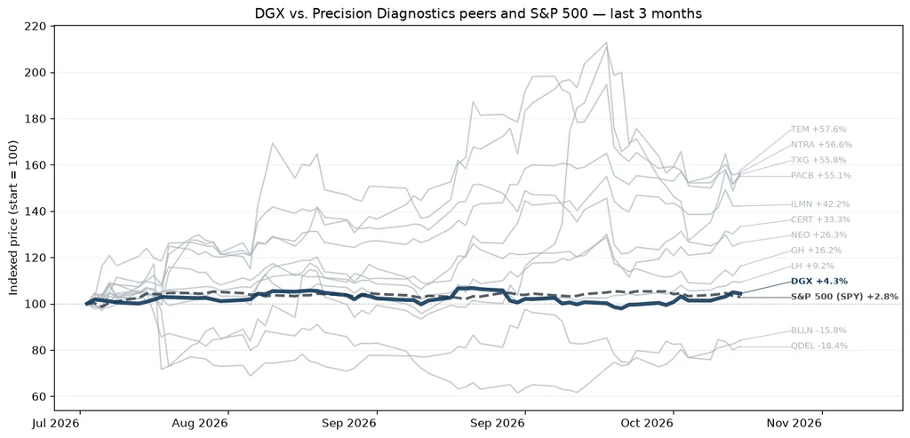

#### Earnings Call Summary

Quest Diagnostics reported strong Q3 2026 performance, with revenues growing 10% year-over-year and adjusted EPS up over 15% to $3.00, beating estimates of $2.875. Growth was driven by sustained demand across physician, hospital, and consumer channels, alongside productivity gains from automation and AI. Consequently, management raised full-year 2026 revenue and earnings guidance.

#### At a Glance

- **Quest Diagnostics Beats Earnings Estimates:** Quest Diagnostics reported Q3 2026 adjusted EPS of $3.00, beating the estimated $2.875, and posted total revenues of $3.097 billion, which surpassed the estimated $3.052 billion.
- **Strong Requisition Volumes Drive Growth:** The company's organic requisition volume surged 14.4% year-over-year, which helped power a 10% overall revenue increase driven by strong demand across physician, hospital, and consumer channels.
- **Full Year Guidance Raised Across Board:** Management raised its full-year 2026 outlook, now expecting adjusted diluted EPS to range between $11.25 and $11.35 and revenue to reach between $12.065 billion and $12.105 billion.
- **Consumer Health Growth and Apple Expansion:** Quest's consumer health channel is expected to grow more than 30% for the full year, supported by an upcoming integration allowing direct lab ordering through the Apple Health app.
- **AI and Automation Boost Margins:** Adjusted operating margin expanded 40 basis points to 16.7%, driven by productivity initiatives from automation and AI that helped offset wage inflation.

#### Key Moments from the Call

- **15m 13s — Raised Full-Year 2026 Guidance:** Driven by strong Q3 2026 organic performance, Quest raised and narrowed full-year guidance, projecting revenue growth of 9.3%-9.7% and adjusted EPS of $11.25-$11.35, which will please investors looking for stable growth momentum.
- **16m 32s — PAMA 2027 Revenue Headwinds Sized:** Management clarified that the potential 2027 PAMA impact is roughly 1% of total revenues, with a cumulative impact under 1.3% through 2029. Investors will be reassured that Quest plans to mitigate this via infrastructure efficiencies without hurting growth.
- **28m 8s — Accretive Consumer Channel Growth:** The consumer channel is projected to grow over 30% for the full year. Crucially for investors, management revealed that consumer margins are accretive to overall operating margins due to high test-density and a lack of patient concessions.
- **32m 31s — Cybersecurity Incident Filed:** Quest addressed an 8-K filing regarding unauthorized access to a test ordering system. While the investigation is early, management noted it has not materially disrupted business operations or patient care, balancing potential investor concerns.

### Molina Healthcare (MOH) +5.9%

**Reported:** October 22, 2026 · [Google Finance earnings page](https://www.google.com/finance/quote/MOH:NYSE?tab=earnings&hl=en)

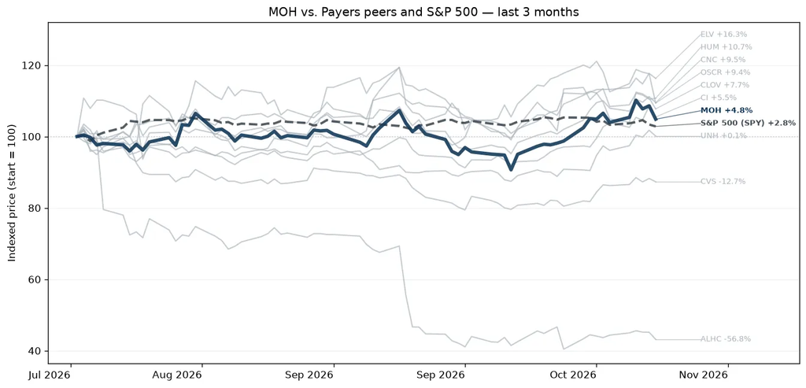

#### Earnings Call Summary

Molina Healthcare reported Q3 2026 adjusted EPS of $0.89 on premium revenue of $10.5B, delivering a consolidated medical cost ratio (MCR) of 92.9% and an adjusted pre-tax margin of 0.6% amid a challenging medical cost environment. Performance across Medicaid (93% MCR), Medicare (93% MCR), and Marketplace (92.5% MCR) segments was in line with expectations.

#### At a Glance

- **Molina Exceeds EPS and Revenue Estimates:** Molina Healthcare reported a reported revenue of $11,082,000,000, outperforming the estimated revenue of $10,859,186,010, and generated an adjusted EPS of $0.89 which beat the consensus estimate of $0.795.
- **Medical Care Ratio Remains Elevated:** The company's consolidated Medical Care Ratio (MCR) stood at 92.9%, up slightly from 92.6% in the prior year's third quarter due to elevated medical costs, though its Medicaid MCR of 93% met internal expectations.
- **Full-Year Guidance Reaffirmed Amid Transitions:** Molina reaffirmed its full-year 2026 adjusted EPS guidance of at least $5.25 and full-year premium revenue of approximately $42 billion, despite accounting for a $1.50 per share impact from its new Florida Medicaid contract launch.
- **Strategic Exit from MAPD Business:** To address profitability pressures, management announced the company will entirely exit its traditional Medicare Advantage Prescription Drug (MAPD) business in 2027 to narrow focus exclusively on the higher-performing dual-eligible population.
- **Strong Preliminary Building Blocks for 2027:** Management introduced an early 2027 framework projecting adjusted EPS building blocks to exceed $9.50 per share, supported by an anticipated 6% average Medicaid rate increase and contract maturity.
- **Stock Dropped on Margin Pressures:** Molina Healthcare's stock dropped roughly 3.5% following the announcement as investors reacted to a lower preliminary 2027 premium outlook and tight 0.6% adjusted pre-tax margins caused by the ongoing medical cost squeeze.

#### Key Moments from the Call

- **5m 48s — Medicaid Margin Turn and Rate Stabilization:** Management signaled that the imbalance between Medicaid rates and medical trends has stabilized, marking the current cycle as the margin trough. The high 7% initial draft rates for January renewals bolster investor confidence that states are proactively adjusting baselines for rising high-cost drug and behavioral health trends.
- **22m 50s — Robust 2027 Earnings Growth Building Blocks:** Molina's preliminary 2027 EPS target of over $9.50 per share represents a steep increase from 2026 guidance. This will please investors as it captures $4.00 of embedded earnings—including the elimination of Florida CMS startup and MAPD exit losses—alongside a Marketplace recovery, without relying on legacy Medicaid margin expansion.
- **26m 44s — Managed Work Requirements Attrition Impact:** Addressing top investor anxieties regarding impending federal work requirements, Molina forecast a manageable 6% organic membership decline for 2027. Early data from Nebraska reveals gentle state implementation and a massive 20% medical frailty exemption rate, indicating a lower-than-feared impact on membership and subsequent acuity shifts.
- **31m 43s — Florida CMS Contract Execution Drag:** The newly implemented $6B Florida CMS contract represents a massive growth catalyst but will depress immediate earnings, creating a $1.00 drag in Q4 2026 via a 99% MCR and 5% pre-tax loss. However, management provided a high-confidence pathway to reach break-even in 2027 by shedding one-time reserves.

## Company Overviews

### UnitedHealth (UNH)

*Payers · $360.3B · 3m -0.6% · 12m +15.3% · 24m -25.9%*

[Google Finance](https://www.google.com/finance/quote/UNH:NYSE?tab=earnings&hl=en)

Diversified healthcare company operating UHC insurance businesses and the Optum health services platform.

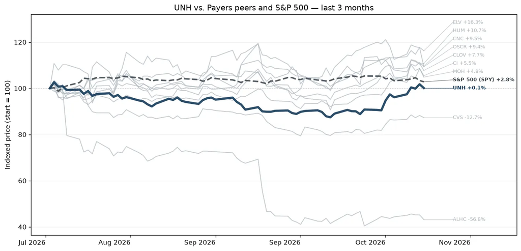

UnitedHealth Group is one of the largest private health insurers and provides medical benefits to about 51 million members globally, including 1 million outside the US as of December 2025. As a leader in employer-sponsored, self-directed, and government-backed insurance plans, UnitedHealth has obtained massive scale in medical insurance. Along with its insurance assets, UnitedHealth's Optum franchises help create a healthcare services colossus that spans everything from pharmaceutical benefits to providing outpatient care and analytics to affiliates and third parties.

### CVS Health (CVS)

*Payers · $118.1B · 3m -13.2% · 12m +14.1% · 24m +65.5%*

[Google Finance](https://www.google.com/finance/quote/CVS:NYSE?tab=earnings&hl=en)

Healthcare retail ecosystem.

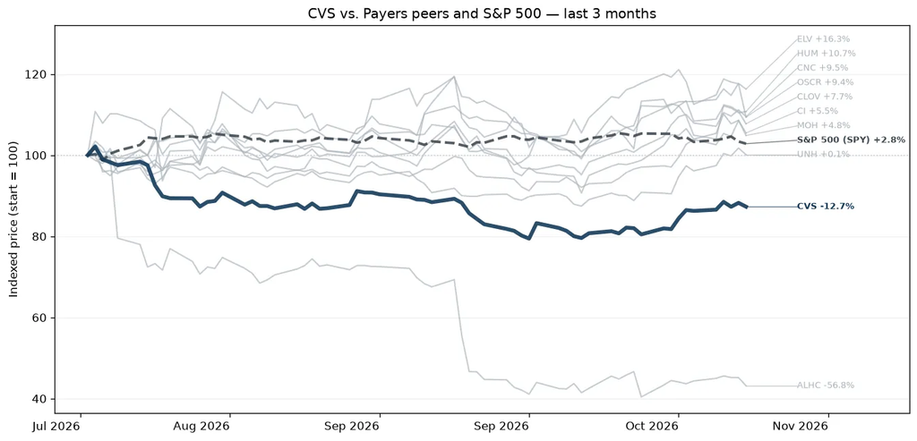

CVS Health offers a diverse set of healthcare services. Its roots are in its retail pharmacy operations, where it operates around 9,000 stores primarily in the US. CVS is also a large pharmacy benefit manager (acquired through Caremark), processing about 2 billion adjusted claims annually. It operates a top-tier health insurer (acquired through Aetna) through which it serves about 26 million medical members. The acquisition of Oak Street Health added primary care services to the mix, which could have significant synergies with all existing business lines.

### Humana (HUM)

*Payers · $43.7B · 3m +8.4% · 12m +45.2% · 24m +61.9%*

[Google Finance](https://www.google.com/finance/quote/HUM:NYSE?tab=earnings&hl=en)

Large payer, Medicare and Medicare Advantage focused.

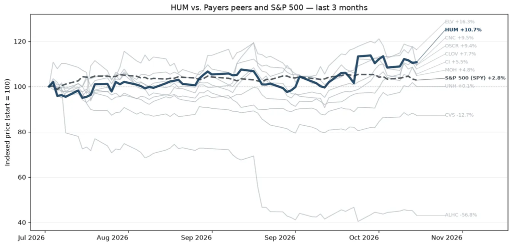

Humana is one of the largest private health insurers in the US, and the firm has built a niche specializing in government-sponsored programs, with nearly all its medical membership stemming from Medicare, Medicaid, and the military's Tricare program. Beyond medical insurance, the company provides other healthcare services, including primary-care services, at-home services, and pharmacy benefit management.

### Oscar Health (OSCR)

*Payers · $9.4B · 3m +9.9% · 12m +60.7% · 24m +91.4%*

[Google Finance](https://www.google.com/finance/quote/OSCR:NYSE?tab=earnings&hl=en)

Tech-focused payer with large exposure to exchange products and ICHRAs.

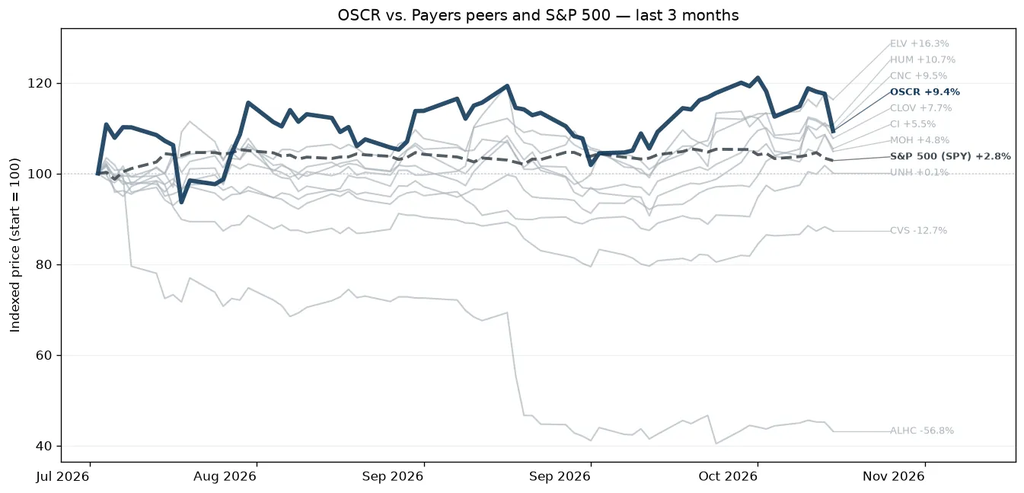

Oscar Health Inc is a healthcare technology company built around a full stack technology platform and a relentless focus on serving its members. It offers Individual & Family plans and health technology solutions that power the healthcare industry. Oscar operates as one segment to sell insurance to individuals, families and employees through the federal and state-run healthcare exchanges formed in conjunction with the Patient Protection and Affordable Care Act (ACA) and leverages its technology platform to provide services via its Oscar offering.

### Molina Healthcare (MOH)

*Payers · $10.2B · 3m +5.9% · 12m +28.1% · 24m -35.8%*

[Google Finance](https://www.google.com/finance/quote/MOH:NYSE?tab=earnings&hl=en)

Managed-care company providing health insurance through government programs.

Molina Healthcare Inc provides medical insurance plans through Medicaid, the individual exchanges, and Medicare. The company operates in four reportable segments consisting of: 1) Medicaid; 2) Medicare; 3) Marketplace; and 4) Other. It manages health benefit risks for more than 5 million people, with more than 85% of those members coming through contracts with state governments for their Medicaid programs. Medicaid contracts in four states-California, New York, Texas, and Washington-account for over half of its enrollees.

### Cigna (CI)

*Payers · $73.7B · 3m +6.0% · 12m +1.7% · 24m -3.1%*

[Google Finance](https://www.google.com/finance/quote/CI:NYSE?tab=earnings&hl=en)

Employer-focused health insurance company.

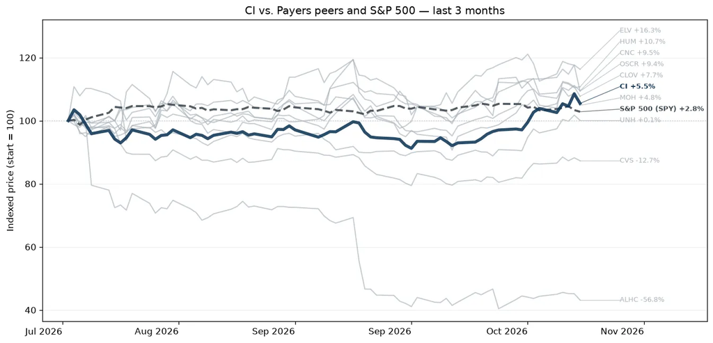

Cigna primarily provides pharmacy benefit management and health insurance services. Its PBM and specialty pharmacy services, which were greatly expanded by its 2018 merger with Express Scripts, are mostly sold to health insurance plans and employers. Its largest PBM contract is with the Department of Defense, and it recently won a multiyear deal with top-tier insurer Centene. In health insurance and other benefits, Cigna primarily serves employers through self-funding arrangements, and the company operates mostly in the US with 16 million US and 2 million international medical members covered as of December 2025.

### Elevance (ELV)

*Payers · $81.5B · 3m +16.5% · 12m +28.5% · 24m +3.5%*

[Google Finance](https://www.google.com/finance/quote/ELV:NYSE?tab=earnings&hl=en)

Health insurance company, previously named Anthem.

Elevance Health remains one of the leading health insurers in the US, providing medical benefits to 45 million medical members at the end of 2025. The company offers employer, individual, and government-sponsored coverage plans. Elevance differs from its peers in its unique position as the largest single provider of Blue Cross Blue Shield branded coverage, operating as the licensee for the Blue Cross Blue Shield Association in 14 states. Through acquisitions, such as the Amerigroup deal in 2012 and MMM in 2021, Elevance's reach expands beyond those states in government-sponsored programs, such as Medicaid and Medicare Advantage plans, too. It is also an emerging player in pharmacy benefit management and other healthcare services.

### Clover Health (CLOV)

*Payers · $2.2B · 3m +6.5% · 12m +20.4% · 24m +17.3%*

[Google Finance](https://www.google.com/finance/quote/CLOV:NASDAQ?tab=earnings&hl=en)

American healthcare company company providing Medicare Advantage insurance plans.

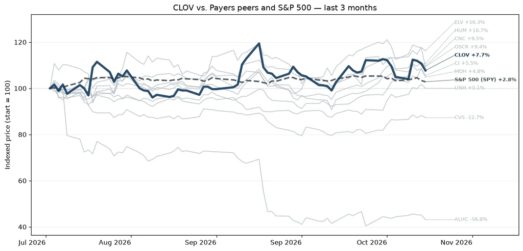

Clover Health Investments Corp is a healthcare technology company. It focuses on empowering Medicare physicians to proactively manage chronic diseases through its proprietary software platform, Clover Assistant. This cloud-based solution provides personalized insights to physicians, enabling early detection and management of chronic conditions. It operates in one segment: Insurance, through which it offers PPO and HMO plans to Medicare Advantage members in several states.